# What makes some languages more difficult to learn than others?

## by Lauren Marar

What linguistic features make some languages harder to learn than others? This analysis will look at langauge difficulty for native English speakers and examine the linguistic features that distinguish easer and more difficult languages. (Note languages will be referred to as "easier" and "difficult" for short, to represent their relative difficulty for an English speaker. Inherent difficult independent of native language is not explored in this project.)

This analysis will utilize two datasets:

1. The World Atlas of Language Structures (WALS), which catalogues language features for 2,679 languages: https://www.kaggle.com/rtatman/world-atlas-of-language-structures This data comes in both wide and long format. The long format will be used for the bulk of the analysis but the wide format will be pulled in as well as it contains additional information about the language regions.
2. Language difficulty ratings as determined by the Foreign Service for 67 frequently studied languages: https://www.state.gov/m/fsi/sls/c78549.htm

## Preliminary Wrangling

```python
# Import all packages and set plots to be embedded inline
import numpy as np
import pandas as pd
import matplotlib.pyplot as plt
import seaborn as sb
import requests
import io
from io import BytesIO
import warnings
warnings.filterwarnings('ignore')
import matplotlib.pyplot as plt

%matplotlib inline
```

### Source 1a: Language Features - Long

```python
# Import the long version of the WALS dataset to be used for the analysis of language features.
features = pd.read_csv(r'C:\Users\Admin\Google Drive\Udacity\data-viz-proj\wals-data.csv')
features.head()
```

|  | File | ID | Language_ID | Language_name | Parameter_ID | Parameter_name | Value | Source | Comment |
| --- | --- | --- | --- | --- | --- | --- | --- | --- | --- |
| 0 | wals-chapter-50 | 50A-bec | bec | Bengali (Chittagong) | 50A | Asymmetrical Case-Marking | Subtractive-quantitatively asymmetrical | Ucida-1970[29-45, 52-53] | NaN |
| 1 | wals-chapter-50 | 50A-tda | tda | Toda | 50A | Asymmetrical Case-Marking | Symmetrical | Emeneau-1984[69-89] | NaN |
| 2 | wals-chapter-50 | 50A-frw | frw | Frisian (Western) | 50A | Asymmetrical Case-Marking | Additive-quantitatively asymmetrical | Tiersma-1985[54-55, 61-65] | NaN |
| 3 | wals-chapter-50 | 50A-ots | ots | Otomí (Sierra) | 50A | Asymmetrical Case-Marking | No case-marking | Voigtlander-and-Echegoyen-1985[passim] | NaN |
| 4 | wals-chapter-50 | 50A-mdr | mdr | Madurese | 50A | Asymmetrical Case-Marking | No case-marking | Davies-1999[passim] | NaN |

```python
features_clean = features.copy()
```

```python
# Remove columns that aren't needed
features_clean = features_clean[['Language_name','Parameter_ID','Parameter_name','Value']]
```

### Source 1b: Language Features - Wide

```python
# Import the wide verson of the World Atlas of Language Structures dataset.
# With one row per language, this dataset also includes languages' family. This dataset will be used to
#   analyze data by language family.
lang_info = pd.read_csv(r'C:\Users\Admin\Google Drive\Udacity\data-viz-proj\language.csv')
lang_info.head()
```

|  | wals_code | iso_code | glottocode | Name | latitude | longitude | genus | family | macroarea | countrycodes | ... | 137B M in Second Person Singular | 136B M in First Person Singular | 109B Other Roles of Applied Objects | 10B Nasal Vowels in West Africa | 25B Zero Marking of A and P Arguments | 21B Exponence of Tense-Aspect-Mood Inflection | 108B Productivity of the Antipassive Construction | 130B Cultural Categories of Languages with Identity of 'Finger' and 'Hand' | 58B Number of Possessive Nouns | 79B Suppletion in Imperatives and Hortatives |
| --- | --- | --- | --- | --- | --- | --- | --- | --- | --- | --- | --- | --- | --- | --- | --- | --- | --- | --- | --- | --- | --- |
| 0 | aab | NaN | NaN | Arapesh (Abu) | -3.450000 | 142.950000 | Kombio-Arapesh | Torricelli | NaN | PG | ... | NaN | NaN | NaN | NaN | NaN | NaN | NaN | NaN | NaN | NaN |
| 1 | aar | aiw | aari1239 | Aari | 6.000000 | 36.583333 | South Omotic | Afro-Asiatic | Africa | ET | ... | NaN | NaN | NaN | NaN | NaN | NaN | NaN | NaN | NaN | NaN |
| 2 | aba | aau | abau1245 | Abau | -4.000000 | 141.250000 | Upper Sepik | Sepik | Papunesia | PG | ... | NaN | NaN | NaN | NaN | NaN | NaN | NaN | NaN | NaN | NaN |
| 3 | abb | shu | chad1249 | Arabic (Abbéché Chad) | 13.833333 | 20.833333 | Semitic | Afro-Asiatic | Africa | TD | ... | NaN | NaN | NaN | NaN | NaN | NaN | NaN | NaN | NaN | NaN |
| 4 | abd | abi | abid1235 | Abidji | 5.666667 | -4.583333 | Kwa | Niger-Congo | Africa | CI | ... | NaN | NaN | NaN | NaN | NaN | NaN | NaN | NaN | NaN | NaN |

5 rows × 202 columns

```python
lang_info_clean = lang_info.copy()
```

```python
lang_info_clean = lang_info_clean[['Name','genus','family','macroarea']]
```

### Source 2: Language Difficulties

The following source lists 67 languages ranked by the difficulty rating assigned by the Foreign Service.

The language difficulties are derived from the expected time it would take a native English speaker to reach "Professional Working Proficiency" (a "score of 'Speaking-3/Reading-3' on the Interagency Language Roundtable scale").

> Category I

> Category II

> Category III

> Category IV

English will be added as "level 0" for a comparison point.

```python
# Import the language difficulty dataset
levels = pd.read_csv(r'C:\Users\Admin\Google Drive\Udacity\data-viz-proj\language_difficulties.csv')
```

```python
levels_clean = levels.copy()
# Coming from a webpage, this dataset will require a bit of tidying and cleaning
#   before it will be ready to merge with the language structure datasets.
```

```python
# Isolate study time from language name. The time is also repeated in the difficulty column.
levels_clean[['language','study_weeks']] = levels_clean['language'].str.split(' \(',n=1,expand=True)
```

```python
levels_clean.groupby('study_weeks').count()
```

| study_weeks | language | difficulty |
| --- | --- | --- |
| 24 weeks) | 8 | 8 |
| 30 weeks) | 1 | 1 |

```python
levels_clean['study_weeks'] = levels_clean['study_weeks'].str.strip(' weeks)')
```

```python
#Isolate the Category from the difficulty column
levels_clean[['difficulty','duration']] = levels_clean['difficulty'].str.split(': ',n=0,expand=True)
levels_clean.head(10)
```

|  | language | difficulty | study_weeks | duration |
| --- | --- | --- | --- | --- |
| 0 | Danish | Category I Languages | 24 | 24-30 weeks (600-750 class hours) |
| 1 | Italian | Category I Languages | 24 | 24-30 weeks (600-750 class hours) |
| 2 | Romanian | Category I Languages | 24 | 24-30 weeks (600-750 class hours) |
| 3 | Dutch | Category I Languages | 24 | 24-30 weeks (600-750 class hours) |
| 4 | Norwegian | Category I Languages | 24 | 24-30 weeks (600-750 class hours) |
| 5 | Spanish | Category I Languages | 24 | 24-30 weeks (600-750 class hours) |
| 6 | French | Category I Languages | 30 | 24-30 weeks (600-750 class hours) |
| 7 | Portuguese | Category I Languages | 24 | 24-30 weeks (600-750 class hours) |
| 8 | Swedish | Category I Languages | 24 | 24-30 weeks (600-750 class hours) |
| 9 | German | Category II Languages | None | Approximately 36 weeks (900 class hours) |

```python
#Examine the range of times
levels_clean.groupby('duration').count()
```

| duration | language | difficulty | study_weeks |
| --- | --- | --- | --- |
| 24-30 weeks (600-750 class hours) | 9 | 9 | 9 |
| 88 weeks (2200 class hours) | 5 | 5 | 0 |
| Approximately 36 weeks (900 class hours) | 5 | 5 | 0 |
| Approximately 44 weeks (1100 class hours) | 48 | 48 | 0 |

```python
# Hours and weeks are redundant (both reflecting the same ratio between levels). Parse out weeks for analysis.
levels_clean[['study_weeks_2','study_hours']] = levels_clean['duration'].str.split('weeks',n=0,expand=True)
```

```python
levels_clean.study_weeks_2 = levels_clean.study_weeks_2.str.extract('(\d+)')
levels_clean.tail()
```

|  | language | difficulty | study_weeks | duration | study_weeks_2 | study_hours |
| --- | --- | --- | --- | --- | --- | --- |
| 62 | Arabic | Category IV Languages | None | 88 weeks (2200 class hours) | 88 | (2200 class hours) |
| 63 | Japanese | Category IV Languages | None | 88 weeks (2200 class hours) | 88 | (2200 class hours) |
| 64 | Chinese – Cantonese | Category IV Languages | None | 88 weeks (2200 class hours) | 88 | (2200 class hours) |
| 65 | Korean | Category IV Languages | None | 88 weeks (2200 class hours) | 88 | (2200 class hours) |
| 66 | Chinese – Mandarin | Category IV Languages | None | 88 weeks (2200 class hours) | 88 | (2200 class hours) |

```python
# Coalesce study_weeks and study_weeks_2. For Category I Languages, keep study_weeks as it
#  specified the hours within the 24-30 range, whereas study_weeks_2 selected the minimum number in the range.
levels_clean['weeks'] = levels_clean.study_weeks.combine_first(levels_clean.study_weeks_2)
# Reference: https://stackoverflow.com/questions/38152389/coalesce-values-from-2-columns-into-a-single-column-in-a-pandas-dataframe
```

```python
#Correct hours for French is under weeks.
levels_clean.query('language=="French"')
```

|  | language | difficulty | study_weeks | duration | study_weeks_2 | study_hours | weeks |
| --- | --- | --- | --- | --- | --- | --- | --- |
| 6 | French | Category I Languages | 30 | 24-30 weeks (600-750 class hours) | 24 | (600-750 class hours) | 30 |

```python
#Drop excess columns. We can remove study_hours as well as the difference in hours between each category is the same ratio as the difference in weeks.
levels_clean.drop('study_weeks',axis=1,inplace=True)
levels_clean.drop('study_weeks_2',axis=1,inplace=True)
levels_clean.drop('study_hours',axis=1,inplace=True)
levels_clean.drop('duration',axis=1,inplace=True)
levels_clean.head()
```

|  | language | difficulty | weeks |
| --- | --- | --- | --- |
| 0 | Danish | Category I Languages | 24 |
| 1 | Italian | Category I Languages | 24 |
| 2 | Romanian | Category I Languages | 24 |
| 3 | Dutch | Category I Languages | 24 |
| 4 | Norwegian | Category I Languages | 24 |

```python
# Convert weeks data type to integer so that it can be used as a numerical variable.
levels_clean.weeks = levels_clean.weeks.astype(int)
levels_clean.info()
```

```
<class 'pandas.core.frame.DataFrame'>
RangeIndex: 67 entries, 0 to 66
Data columns (total 3 columns):
language      67 non-null object
difficulty    67 non-null object
weeks         67 non-null int32
dtypes: int32(1), object(2)
memory usage: 1.4+ KB
```

```python
levels_clean.groupby('difficulty').count()
```

| difficulty | language | weeks |
| --- | --- | --- |
| Category I Languages | 9 | 9 |
| Category II Languages | 5 | 5 |
| Category III Languages | 48 | 48 |
| Category IV Languages | 5 | 5 |

```python
levels_clean.difficulty = levels_clean.difficulty.replace({'Category I Languages':1,
                                                          'Category II Languages':2,
                                                          'Category III Languages':3,
                                                          'Category IV Languages':4})

levels_clean.groupby('difficulty').count()
```

| difficulty | language | weeks |
| --- | --- | --- |
| 1 | 9 | 9 |
| 2 | 5 | 5 |
| 3 | 48 | 48 |
| 4 | 5 | 5 |

```python
# Assign value of 0 to English
add_eng = {'language':['English'],
          'difficulty':0,
          'weeks':0}
```

```python
eng_df = pd.DataFrame(data=add_eng)
```

```python
levels_clean = levels_clean.append(eng_df)
levels_clean.tail()
```

|  | language | difficulty | weeks |
| --- | --- | --- | --- |
| 63 | Japanese | 4 | 88 |
| 64 | Chinese – Cantonese | 4 | 88 |
| 65 | Korean | 4 | 88 |
| 66 | Chinese – Mandarin | 4 | 88 |
| 0 | English | 0 | 0 |

### Merge `features_clean` and `levels_clean`

```python
# Identify languages that did not merge due to different naming conventions
lang_merge = pd.merge(levels_clean, features_clean,
                     how='outer', left_on='language', right_on='Language_name',
                     suffixes=('_level','_feat'), indicator=True)

lang_merge.groupby('_merge').count()
```

| _merge | language | difficulty | weeks | Language_name | Parameter_ID | Parameter_name | Value |
| --- | --- | --- | --- | --- | --- | --- | --- |
| left_only | 14 | 14 | 14 | 0 | 0 | 0 | 0 |
| right_only | 0 | 0 | 0 | 71429 | 71429 | 71429 | 71429 |
| both | 4991 | 4991 | 4991 | 4991 | 4991 | 4991 | 4991 |

```python
lang_merge['language'][lang_merge['_merge']=='left_only']
```

```
1778                 Hebrew
1856                Kurdish
1983              Mongolian
2766                  Farsi
2767                  Greek
2921                 Kyrgyz
3067         Serbo-Croatian
3068              Slovenian
3069                 Tajiki
3295               Armenian
4346                Tibetan
4546                 Arabic
4697    Chinese – Cantonese
4846     Chinese – Mandarin
Name: language, dtype: object
```

```python
features_clean['lang_alias'] = features_clean['Language_name']
```

As the Foreign Service list did not include standard language codes, I visually mapped the languages whose names did not match the WALS dataset. Only a few languages did not have a one-to-one match. Here was the general decision-making process for matching the languages:

- Arabic - WALS includes numerous Arabic dialects as well as Modern Standards Arabic. I mapped to Modern Standard and one dialect (Egyptian, as it had the most data and is a widely known dialect).
- Mongolian - WALS has several Mongolic languages. I mapped to Khalkha, which according to Wikipedia, is the most strongly associted with the country of Mongolia.

```python
features_clean.lang_alias = features_clean.lang_alias.replace({'Hebrew (Modern)':'Hebrew',
                                                                 'Kurdish (Central)':'Kurdish',
                                                                 'Khalkha':'Mongolian',
                                                                 'Persian':'Farsi',
                                                                 'Greek (Modern)':'Greek',
                                                                 'Kirghiz':'Kyrgyz',
                                                                 'Serbian-Croatian':'Serbo-Croatian',
                                                                 'Slovene':'Slovenian',
                                                                 'Tajik':'Tajiki',
                                                                 'Armenian (Eastern)':'Armenian',
                                                                 'Tibetan (Standard Spoken)':'Tibetan',
                                                                 'Arabic (Egyptian)':'Arabic',
                                                                 'Arabic (Modern Standard)':'Arabic',
                                                                 'Cantonese':'Chinese – Cantonese',
                                                                 'Mandarin':'Chinese – Mandarin'})
```

```python
lang_merge = pd.merge(levels_clean, features_clean,
                     how='outer', left_on='language', right_on='lang_alias',
                     suffixes=('_level','_feat'), indicator=True)

lang_merge.groupby('_merge').count()
```

| _merge | language | difficulty | weeks | Language_name | Parameter_ID | Parameter_name | Value | lang_alias |
| --- | --- | --- | --- | --- | --- | --- | --- | --- |
| left_only | 0 | 0 | 0 | 0 | 0 | 0 | 0 | 0 |
| right_only | 0 | 0 | 0 | 69975 | 69975 | 69975 | 69975 | 69975 |
| both | 6445 | 6445 | 6445 | 6445 | 6445 | 6445 | 6445 | 6445 |

```python
# Create dataset of langauges with difficulty rankings
lang_merge = lang_merge[['language','difficulty','Parameter_ID','Value']]
lang_train = lang_merge.dropna(subset=['difficulty'])
lang_train.info()
```

```
<class 'pandas.core.frame.DataFrame'>
Int64Index: 6445 entries, 0 to 6444
Data columns (total 4 columns):
language        6445 non-null object
difficulty      6445 non-null float64
Parameter_ID    6445 non-null object
Value           6445 non-null object
dtypes: float64(1), object(3)
memory usage: 251.8+ KB
```

### Merge `levels_clean` and `structure_clean`

```python
lang_info_clean['lang_alias'] = lang_info_clean['Name']
```

```python
lang_info_clean.lang_alias = lang_info_clean.lang_alias.replace({'Hebrew (Modern)':'Hebrew',
                                                                 'Kurdish (Central)':'Kurdish',
                                                                 'Khalkha':'Mongolian',
                                                                 'Persian':'Farsi',
                                                                 'Greek (Modern)':'Greek',
                                                                 'Kirghiz':'Kyrgyz',
                                                                 'Serbian-Croatian':'Serbo-Croatian',
                                                                 'Slovene':'Slovenian',
                                                                 'Tajik':'Tajiki',
                                                                 'Armenian (Eastern)':'Armenian',
                                                                 'Tibetan (Standard Spoken)':'Tibetan',
                                                                 'Arabic (Egyptian)':'Arabic',
                                                                 'Arabic (Modern Standard)':'Arabic',
                                                                 'Cantonese':'Chinese – Cantonese',
                                                                 'Mandarin':'Chinese – Mandarin'})
```

```python
lang_levels_merge = pd.merge(levels_clean, lang_info_clean,
                     how='outer', left_on='language', right_on='lang_alias',
                     suffixes=('_level','_struct'), indicator=True)

lang_levels_merge.groupby('_merge').count()
```

| _merge | language | difficulty | weeks | Name | genus | family | macroarea | lang_alias |
| --- | --- | --- | --- | --- | --- | --- | --- | --- |
| left_only | 0 | 0 | 0 | 0 | 0 | 0 | 0 | 0 |
| right_only | 0 | 0 | 0 | 2610 | 2610 | 2610 | 2587 | 2610 |
| both | 69 | 69 | 69 | 69 | 69 | 69 | 69 | 69 |

## Data Exploration

### 1. How much do we know about the linguistic features in the dataset?

#### A look at data completness

The WALS dataset is actually a compilation of numerous sources on languages, "gathered from descriptive materials (such as reference grammars) by a team of 55 authors" (https://wals.info/). This means that the individual data sources contributing to the database may each cover a different range of languages, and therefore, we will not have data on all the features for all the languages in the dataset.

Let's get a sense of which features we have the most and least data on, in terms of number of languages with values for the feature. WALS often includes "NONE" as one of the values for a feature, so right now we are looking at whether the feature value is known for a given language, not whether or not the language posesses a certain feature.

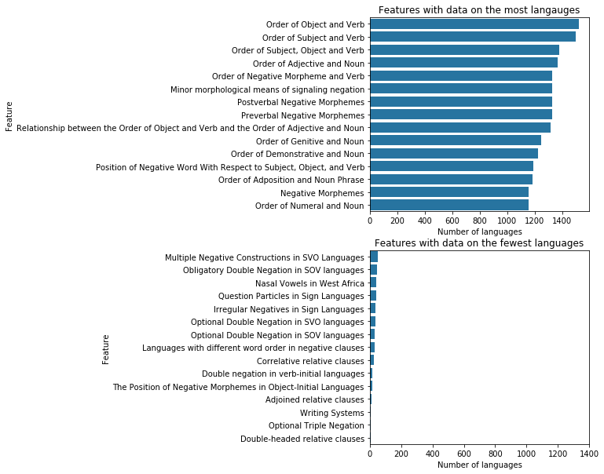

```python
base_color = sb.color_palette('PuBu')[4]

order = features_clean['Parameter_name'].value_counts()

ax1 = plt.figure(figsize=[5,10])
plt.subplot(2, 1, 1)
sb.countplot(data=features_clean,y='Parameter_name',color=base_color,order=order.iloc[:15].index)
plt.xlabel('Number of languages')
plt.ylabel('Feature')
plt.title('Features with data on the most langauges')

ax2 = plt.subplot(2, 1, 2)
sb.countplot(data=features_clean,y='Parameter_name',color=base_color,order=order.iloc[177:192].index)
plt.title('Features with data on the fewest languages')
plt.xlabel('Number of languages')
plt.ylabel('Feature')
ax2.set_xlim([0,1400]);
```

As you can see, some features, like the order of the subject/object/verb in a sentence, are well known across many languages. Other features are very niche and cover very few languages, such as the "position of negative morphemes in object0initial laguages".

### 2. What is the distribution of difficulty ratings across the dataset?

#### How difficult are most languages (in the dataset)?

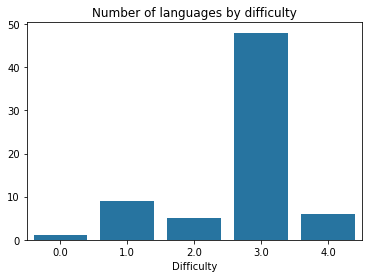

```python
sb.countplot(data=lang_levels_merge, x='difficulty',color=base_color)
plt.xlabel('Difficulty')
plt.ylabel('')
plt.title('Number of languages by difficulty');
```

By far the most common difficulty level for the languages with ratings is category III.

#### How long does it take to learn a more difficult language, incomparison with an easier language?

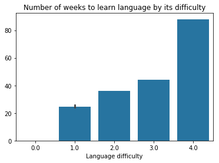

```python
sb.barplot(data=lang_levels_merge,x='difficulty',y='weeks',color=base_color)
plt.xlabel('Language difficulty')
plt.ylabel('')
plt.title('Number of weeks to learn language by its difficulty');
```

There is a non-linear relationship between the language difficulty rating and the number of weeks estimated to learn the language. Learning a category IV language is expected to take nearly twice as long as learning a category III language, whereas the difference between learning a category III and a category II language is relatively small.

#### How does languag difficulty vary by language family?

```python
families = lang_levels_merge.family.value_counts()
```

```python
lang_levels_merge.head()
```

|  | language | difficulty | weeks | Name | genus | family | macroarea | lang_alias | _merge |
| --- | --- | --- | --- | --- | --- | --- | --- | --- | --- |
| 0 | Danish | 1.0 | 24.0 | Danish | Germanic | Indo-European | Eurasia | Danish | both |
| 1 | Italian | 1.0 | 24.0 | Italian | Romance | Indo-European | Eurasia | Italian | both |
| 2 | Romanian | 1.0 | 24.0 | Romanian | Romance | Indo-European | Eurasia | Romanian | both |
| 3 | Dutch | 1.0 | 24.0 | Dutch | Germanic | Indo-European | Eurasia | Dutch | both |
| 4 | Norwegian | 1.0 | 24.0 | Norwegian | Germanic | Indo-European | Eurasia | Norwegian | both |

```python
lang_levels_merge['FSI_set'] = lang_levels_merge['difficulty'].map({np.NaN:'Excluded',
                                                                   0.0:'Included',
                                                                   1.0:'Included',
                                                                   2.0:'Included',
                                                                   3.0:'Included',
                                                                   4.0:'Included'}).astype(str)

# Note: Although English (difficulty 0.0) isn't "included" in the FSI rankings,
#  it is categorized as included because it is implicity reflected in the data.
```

```python
lang_levels_merge.groupby('FSI_set').count()
```

| FSI_set | language | difficulty | weeks | Name | genus | family | macroarea | lang_alias | _merge |
| --- | --- | --- | --- | --- | --- | --- | --- | --- | --- |
| Excluded | 0 | 0 | 0 | 2610 | 2610 | 2610 | 2587 | 2610 | 2610 |
| Included | 69 | 69 | 69 | 69 | 69 | 69 | 69 | 69 | 69 |

```python
FSI_langs = lang_levels_merge.query('FSI_set=="Included"')
```

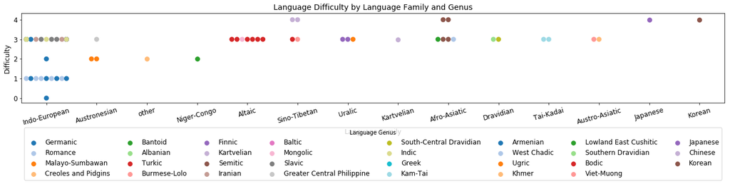

```python
fig = plt.figure(figsize=[23,3])
sb.swarmplot(data=FSI_langs,x='family',y='difficulty',hue='genus',palette='tab20',size=9)
plt.title('Language Difficulty by Language Family and Genus',fontsize=14)
plt.ylabel('Difficulty',fontsize=12)
plt.xlabel('Language Family',fontsize=12)
plt.xticks(rotation=15,fontsize=12)
plt.yticks([0,1,2,3,4],fontsize=12)
plt.legend(bbox_to_anchor=(.5,-.9),loc='lower center',title='Language Genus',ncol=8,fontsize=12);
```

Most languages within a family have the same difficulty rating. Other than the Indo-European family, only Austronesian, Sino-Tibetan, and Afro-Asiatic span more than one difficulty rating. The Indo-European family has the largest range of difficulty levels, split primarily between category I and category III. This is logical as the category I genuses are Germanic and Romance (of Latin origin), which form the roots of English. The category III Indo-European languages comprise primarily the "Indo" part of the family, in other words, the South-Central Dravidian and Indic languages of South Asia.

It looks like there is one Germanic language that is a category II difficulty and another that is a category III. Let's find out which ones they are:

```python
FSI_langs.query('difficulty>=2.0 & genus=="Germanic"')
```

|  | language | difficulty | weeks | Name | genus | family | macroarea | lang_alias | _merge | FSI_set |
| --- | --- | --- | --- | --- | --- | --- | --- | --- | --- | --- |
| 9 | German | 2.0 | 36.0 | German | Germanic | Indo-European | Eurasia | German | both | Included |
| 20 | Icelandic | 3.0 | 44.0 | Icelandic | Germanic | Indo-European | Eurasia | Icelandic | both | Included |

It is interesting how both English and Icelandic are Germanic languages, but are separated by 3 difficulty levels!

### 3. Which language families are represented in the difficulty dataset? Which are missing?

```python
families = lang_levels_merge.family.value_counts()
lang_levels_merge.info()
```

```
<class 'pandas.core.frame.DataFrame'>
Int64Index: 2679 entries, 0 to 2678
Data columns (total 10 columns):
language      69 non-null object
difficulty    69 non-null float64
weeks         69 non-null float64
Name          2679 non-null object
genus         2679 non-null object
family        2679 non-null object
macroarea     2656 non-null object
lang_alias    2679 non-null object
_merge        2679 non-null category
FSI_set       2679 non-null object
dtypes: category(1), float64(2), object(7)
memory usage: 292.0+ KB
```

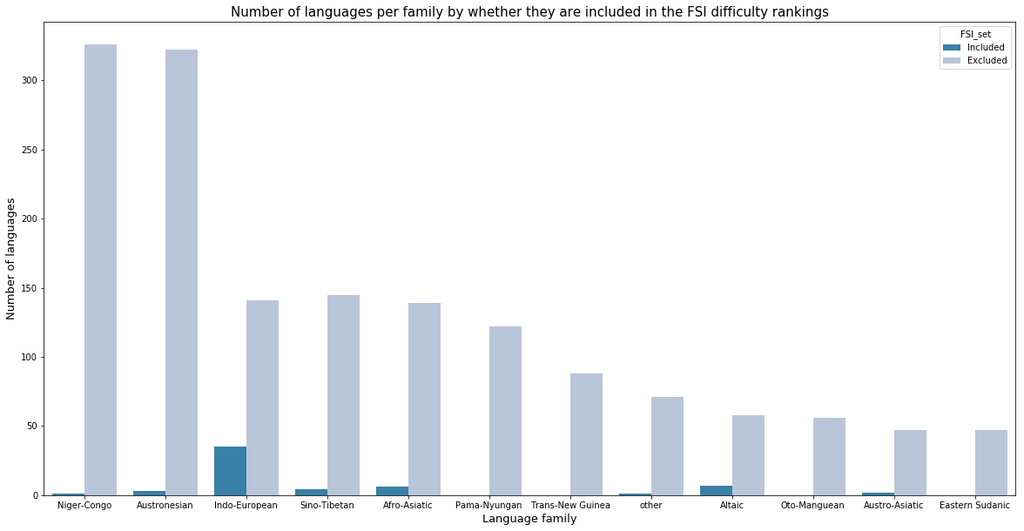

```python
fig=plt.figure(figsize=[20,10])
sb.countplot(data = lang_levels_merge, x = 'family', hue = 'FSI_set', palette='PuBu_r',
             order = families.iloc[:12].index)
plt.xlabel('Language family',fontsize=13)
plt.ylabel('Number of languages',fontsize=13)
plt.title('Number of languages per family by whether they are included in the FSI difficulty rankings',fontsize=15);
```

The chart reveals that the FSI rankings minimally cover the top two most diverse language families, Niger-Congo and Austronesian, which represent over 300 languages each. Note that the bar heights are not proportional to the number of speakers. The top two language families may contain many languages of fewer speakers, in contrast with Indo-European and Sino-Tibetan, which include languages of India and China, covering much of the world's population. Nonetheless, due to minimal data on some of most diverse language families, this analysis might miss out on some distinctive features of African and Polynesian languages.

Anothe observation is that the Altaic language is relatively over-represented by the FSI rankings. Let's take a look at the languages included in that family:

```python
lang_levels_merge.query('family=="Altaic" & FSI_set=="Included"')
```

|  | language | difficulty | weeks | Name | genus | family | macroarea | lang_alias | _merge | FSI_set |
| --- | --- | --- | --- | --- | --- | --- | --- | --- | --- | --- |
| 15 | Azerbaijani | 3.0 | 44.0 | Azerbaijani | Turkic | Altaic | Eurasia | Azerbaijani | both | Included |
| 23 | Mongolian | 3.0 | 44.0 | Khalkha | Mongolic | Altaic | Eurasia | Mongolian | both | Included |
| 28 | Turkish | 3.0 | 44.0 | Turkish | Turkic | Altaic | Eurasia | Turkish | both | Included |
| 36 | Kazakh | 3.0 | 44.0 | Kazakh | Turkic | Altaic | Eurasia | Kazakh | both | Included |
| 37 | Kyrgyz | 3.0 | 44.0 | Kirghiz | Turkic | Altaic | Eurasia | Kyrgyz | both | Included |
| 44 | Turkmen | 3.0 | 44.0 | Turkmen | Turkic | Altaic | Eurasia | Turkmen | both | Included |
| 45 | Uzbek | 3.0 | 44.0 | Uzbek | Turkic | Altaic | Eurasia | Uzbek | both | Included |

The above table shows that the Foreign Service places an extra emphasis on Central Asian languages. All of these languages have a difficulty ranking of III.

Under and overrepresentation of langauge families in specific difficulty categories is likely to impact which linguistic features appear to be more common for specific difficulty groups.

### Occurance of linguistic features by language difficulty

The following section is the exploratory phase of the heart of the question. It will systematically break down linguistic features by language difficulty to look for features that tend to be more prominent in either easier or harder languages.

As we saw above, the number of languages in each difficulty category vary greatly, with category III highly overrepresented. For an even comparison, we need to calculate the relative frequency of linguistic features accross language difficulty.

```python
# Each feature has numerous values, and some of the values are the same across multiple features (ex. the value "none")
#   To ensure values belonging to multiple features aren't aggregated, let's create a concatenated field
#   with the feature's parameter_ID and value:
lang_train['feat_val'] = lang_train['Parameter_ID']+': '+lang_train['Value']
lang_train.head()
```

|  | language | difficulty | Parameter_ID | Value | feat_val |
| --- | --- | --- | --- | --- | --- |
| 0 | Danish | 1.0 | 14A | No fixed stress | 14A: No fixed stress |
| 1 | Danish | 1.0 | 33A | Plural suffix | 33A: Plural suffix |
| 2 | Danish | 1.0 | 81A | SVO | 81A: SVO |
| 3 | Danish | 1.0 | 91A | Degree word-Adjective | 91A: Degree word-Adjective |
| 4 | Danish | 1.0 | 88A | Demonstrative-Noun | 88A: Demonstrative-Noun |

Now we can calculate the relative frequency for each `feat_val`:

```python
n_difficulty = lang_train['difficulty'].value_counts()
```

```python
n_diff = lang_train.groupby(['difficulty']).nunique()
```

```python
n_diff = n_diff.drop(['difficulty','Parameter_ID','Value','feat_val'],axis=1)
```

```python
n_diff.reset_index()
n_diff
```

| difficulty | language |
| --- | --- |
| 0.0 | 1 |
| 1.0 | 9 |
| 2.0 | 5 |
| 3.0 | 48 |
| 4.0 | 5 |

```python
n_value = lang_train.groupby(['difficulty','feat_val']).size().reset_index(name='num_by_level')
```

```python
rel_freq = n_value.merge(n_diff, left_on='difficulty',right_on='difficulty')
```

```python
rel_freq.head()
```

|  | difficulty | feat_val | num_by_level | language |
| --- | --- | --- | --- | --- |
| 0 | 0.0 | 100A: Accusative | 1 | 1 |
| 1 | 0.0 | 101A: Obligatory pronouns in subject position | 1 | 1 |
| 2 | 0.0 | 102A: Only the A argument | 1 | 1 |
| 3 | 0.0 | 103A: No zero realization | 1 | 1 |
| 4 | 0.0 | 104A: A and P do not or do not both occur on t... | 1 | 1 |

```python
rel_freq['rel_freq'] = rel_freq['num_by_level']/rel_freq['language']*100
rel_freq.head()
```

|  | difficulty | feat_val | num_by_level | language | rel_freq |
| --- | --- | --- | --- | --- | --- |
| 0 | 0.0 | 100A: Accusative | 1 | 1 | 100.0 |
| 1 | 0.0 | 101A: Obligatory pronouns in subject position | 1 | 1 | 100.0 |
| 2 | 0.0 | 102A: Only the A argument | 1 | 1 | 100.0 |
| 3 | 0.0 | 103A: No zero realization | 1 | 1 | 100.0 |
| 4 | 0.0 | 104A: A and P do not or do not both occur on t... | 1 | 1 | 100.0 |

```python
rel_freq['ID_num'] = rel_freq.feat_val.str.extract('(\d+)')
```

```python
rel_freq.info()
```

```
<class 'pandas.core.frame.DataFrame'>
Int64Index: 1635 entries, 0 to 1634
Data columns (total 6 columns):
difficulty      1635 non-null float64
feat_val        1635 non-null object
num_by_level    1635 non-null int64
language        1635 non-null int64
rel_freq        1635 non-null float64
ID_num          1635 non-null object
dtypes: float64(2), int64(2), object(2)
memory usage: 89.4+ KB
```

```python
rel_freq.ID_num = rel_freq.ID_num.astype(int)
```

#### The relative frequency of linguistic features by language difficulty

With 67 languages and 144 linguistic features, it would be difficult to visualize the relationship between all of the languages and features in one chart. Therefore, I've broken down the features into meaningful clusters:

- IDs 1-11, 18-19: Consonants and vowels
- ID 12: Syllable Structure
- ID 13: Tone
- IDs 14-17: Stress and rhythm
- IDs 20-26: Inflection and marking
- ID 27: Reduplication
- IDs 28-29: Syncretism
- IDs 30-32: Gender
- IDs 33-36: Plurality
- IDs 37-38: Definite and indefinite articles
- IDs 39-48, 136-137: Inclusive/exclusive distinction, pronouns and marking
- IDs 49-52: Case and comitatives/instrumentals
- IDs 53-56, 131: Numerals and Quantifiers
- IDs 57-59: Possessives
- IDs 60-61: Adjectives
- IDs 61-64: Nouns
- IDs 65-80: Tense and aspect (and suppletion)
- IDs 81-89: Sentence structure and order
- ID 90: Relative clauses
- IDs 91-97: More order
- IDs 98-100: Alignment
- IDs 101-104: Subject and person markers
- IDs 105-111: Constructions (active, passive, reciprocal etc.)
- IDs 112-115, 143: Negation
- ID 116: Polar questions
- IDs 117-120: Predication
- IDs 121-123: Comparative constructions and relativization
- ID 124: 'Want' complement subjects
- IDs 125-128: Clauses
- IDs 129-130, 132-135: Vocabulary
- IDs 138-141: These features will not be analyzed as they apply to very few languages
- ID 142: Para-linguistic usage of clicks
- ID 144: Position of negation

Below is a systematic exploration of the relative frequency of the above categories:

#### Feats 1-11, 18-19: Consonants and Vowels

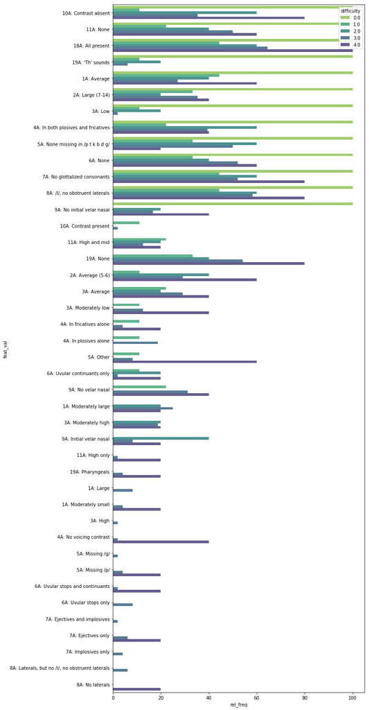

```python
cons_vow = rel_freq.query('ID_num<=11 | 18<=ID_num<=19')
fig=plt.figure(figsize=[10,28])
sb.barplot(data=cons_vow,y='feat_val',x='rel_freq',hue='difficulty',palette='viridis_r',alpha=0.85);
```

*Preliminary Findings:*

- There aren't very distinct differences across difficulty lines, but interestingly more difficult languages are not likely to have more "uncommon consonants" in general (19A).

#### Feat 12: Syllable structure

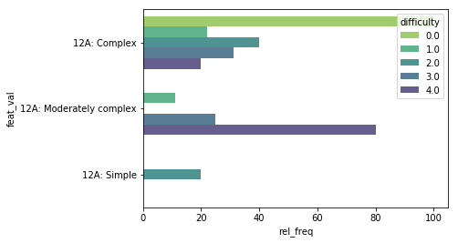

```python
syllable = rel_freq.query('ID_num==12')
sb.barplot(data=syllable,y='feat_val',x='rel_freq',hue='difficulty',palette='viridis_r',alpha=0.85);
```

*Preliminary Findings:*

- Syllable structure does not appear to be strongly related to language difficulty.

#### Feat 13: Tone

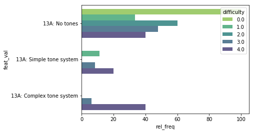

```python
tone = rel_freq.query('ID_num==13')
sb.barplot(data=tone,y='feat_val',x='rel_freq',hue='difficulty',palette='viridis_r',alpha=0.85);
```

*Preliminary Findings:*

- Most languages with a complex tone system are category IV; however, just as many difficult languages have no tone system.

#### Feats 14-17: Stress and rhythm

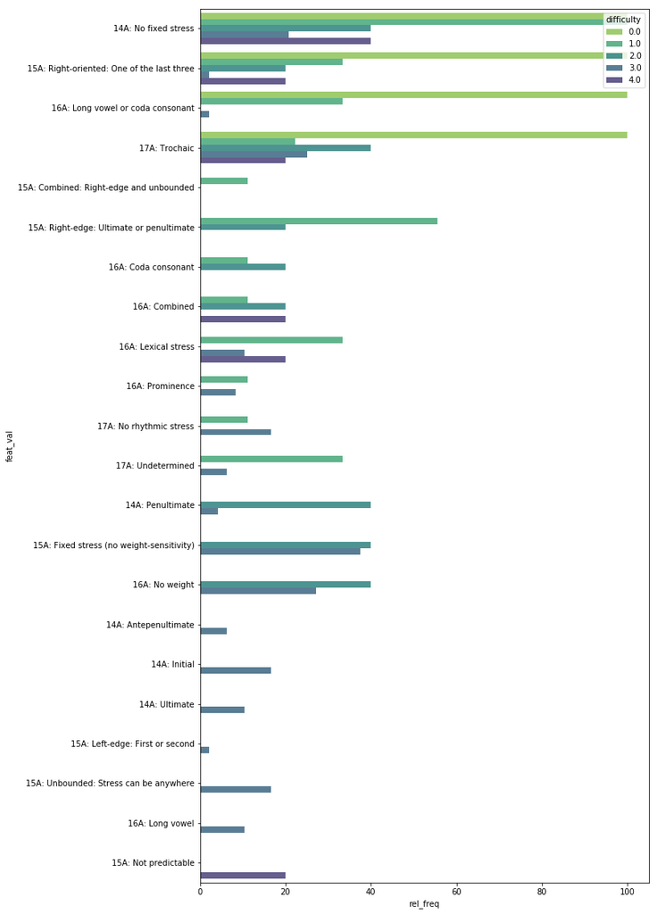

```python
stress = rel_freq.query('ID_num>=14 & ID_num<=17')
fig=plt.figure(figsize=[10,20])
sb.barplot(data=stress,y='feat_val',x='rel_freq',hue='difficulty',palette='viridis_r',alpha=0.85);
```

*Preliminary Findings:*

- No clear lines of diffference in terms of stress and rhythm across difficulty appear.

**Feats 20-26: Inflection and marking**

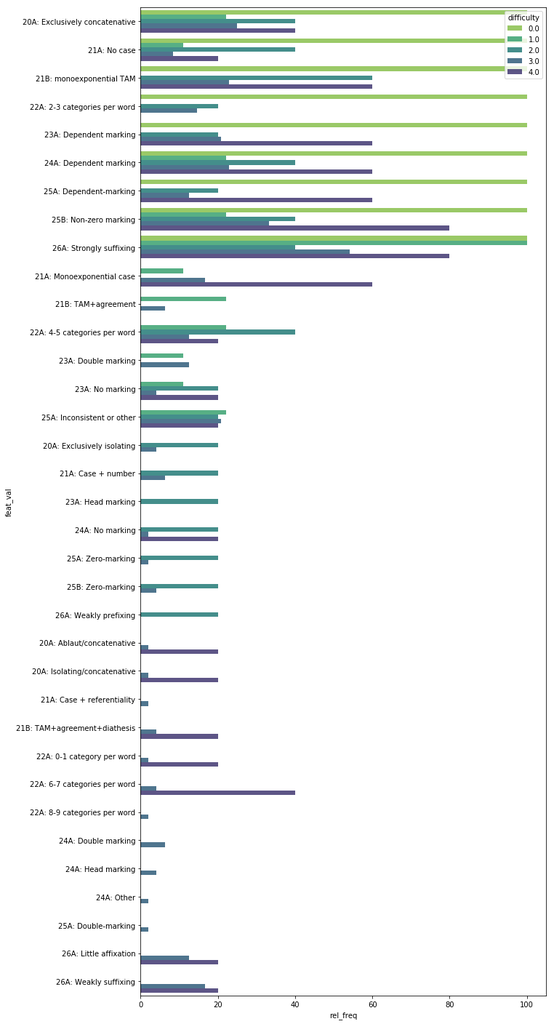

```python
fig=plt.figure(figsize=[10,25])
inflec = rel_freq.query('ID_num>=20 & ID_num<=26')
sb.barplot(data=inflec,y='feat_val',x='rel_freq',hue='difficulty',palette='viridis_r',alpha=0.9);
```

*Preliminary Findings:*

- Inflection and marking do not appear to be the dealbraker for making a language difficult.

**Feat 27: Reduplication**

> The repetition of phonological material within a word for semantic or grammatical purposes https://wals.info/chapter/27

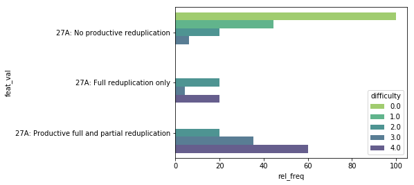

```python
redup = rel_freq.query('ID_num==27')
sb.barplot(data=redup,y='feat_val',x='rel_freq',hue='difficulty',palette='viridis_r',alpha=0.85);
```

*Preliminary Findings*:

- As language difficulty increases, the likelihood of productive reduplication also increases. However, according to WALS, 75% of the 368 languages surveyed use productive reduplication.

**Feats 28-29: Syncretism**

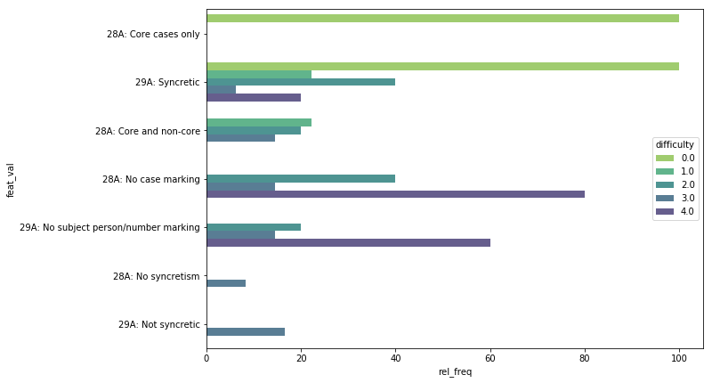

```python
fig=plt.figure(figsize=[10,7])
syncretism = rel_freq.query('ID_num>=28 & ID_num<=29')
sb.barplot(data=syncretism,y='feat_val',x='rel_freq',hue='difficulty',palette='viridis_r',alpha=0.85);
```

*Preliminary Findings:*

- Syncretism does not change linearly from easy to difficult languages.

**Feats 30-32: Gender**

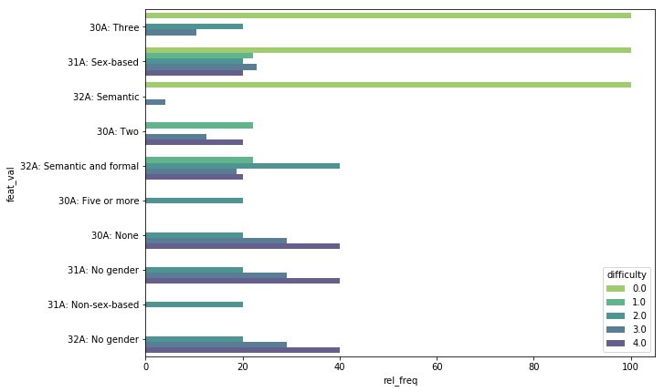

```python
fig=plt.figure(figsize=[10,7])
gender = rel_freq.query('ID_num>=30 & ID_num<=32')
sb.barplot(data=gender,y='feat_val',x='rel_freq',hue='difficulty',palette='viridis_r',alpha=0.85);
```

*Preliminary Findings:*

- There is a lot of variation in gender use, but it does not appear to be associated with difficulty.

**Feats 33-36: Plurality**

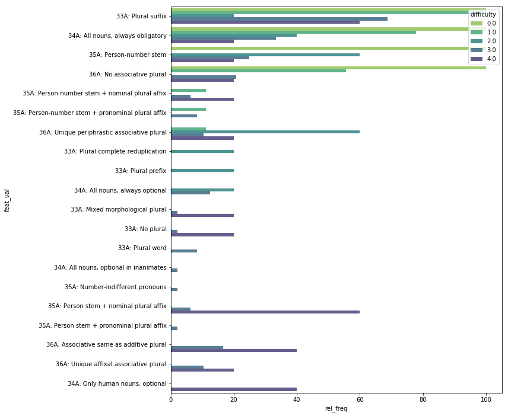

```python
fig=plt.figure(figsize=[10,12])
plurality = rel_freq.query('ID_num>=33 & ID_num<=36')
sb.barplot(data=plurality,y='feat_val',x='rel_freq',hue='difficulty',palette='viridis_r',alpha=0.85);
```

*Preliminary findings:*

- Use of obligatory plurality across all nouns decreases as language complexity increases. Might the lack of consistent application of plurality add to the complexity of the language?
- Personal stem and nominal plural affix (under 35A) is used in 60% of the most difficult languages and absent from the easier languages. This feature only occurs in 22 languages in the full dataset, suggesting this feature may be a unique characteristic of more difficult languages.

**Feats 37-38: Definite and indefinite articles**

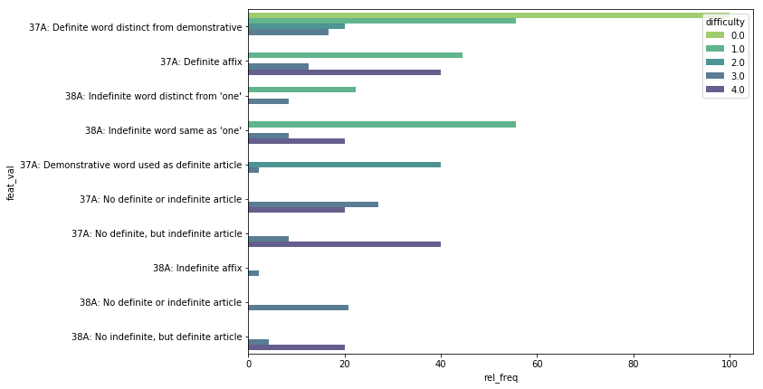

```python
fig=plt.figure(figsize=[10,7])
articles = rel_freq.query('ID_num>=37 & ID_num<=38')
sb.barplot(data=articles,y='feat_val',x='rel_freq',hue='difficulty',palette='viridis_r',alpha=0.85);
```

*Preliminary findings:*

- Easier languages are more likely to have definite word distinction from demonstrative. No category IV langauges have that feature, although 40% have a definite affix.

**Feats 39-48, 136-137: Inclusive/exclusive distinction, pronouns and marking**

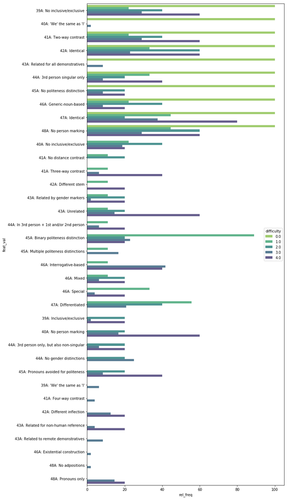

```python
fig=plt.figure(figsize=[10,25])
marking = rel_freq.query('ID_num>=39 & ID_num<=48')
sb.barplot(data=marking,y='feat_val',x='rel_freq',hue='difficulty',palette='viridis_r',alpha=0.85);
```

*Preliminary Findings:*

- Again, there is a lot of diversity across languages, but not necessarily tied to difficulty.

**Feats 49-52: Case and comitatives/instrumentals**

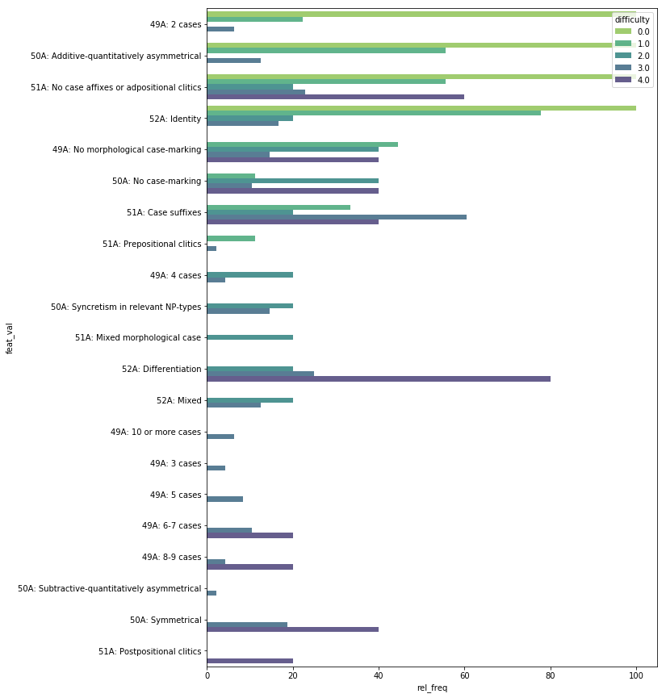

```python
fig=plt.figure(figsize=[10,15])
case = rel_freq.query('ID_num>=49 & ID_num<=52')
sb.barplot(data=case,y='feat_val',x='rel_freq',hue='difficulty',palette='viridis_r',alpha=0.85);
```

*Preliminary Findings:*

- Differentiation (52A) occurs in 80% of category IV languages, as wells some of categories II and III. It does not occure in the category I languages or English. English and the easier languages in turn use identity coding. https://wals.info/chapter/52

**Feats 53-56, 131: Numerals and Quantifiers**

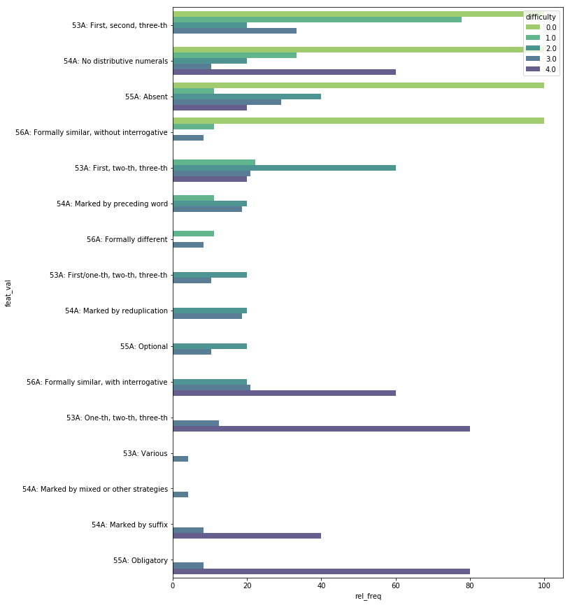

```python
fig=plt.figure(figsize=[10,15])
numerals = rel_freq.query('ID_num>=53 & ID_num<=56')
sb.barplot(data=numerals,y='feat_val',x='rel_freq',hue='difficulty',palette='viridis_r',alpha=0.85);
```

*Preliminary findings:*

- 80% of category IV languages but only 78 of the languages in the dataset have require the use of numeral classifiers. A few cateogry II and II languages have optional classifiers, where as English does not have them at all.

**Feats 57-59: Possessives**

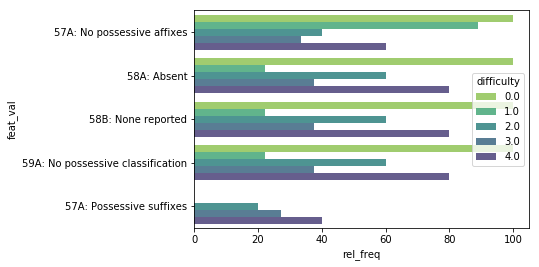

```python
possessive = rel_freq.query('ID_num>=57 & ID_num<=59')
sb.barplot(data=possessive,y='feat_val',x='rel_freq',hue='difficulty',palette='viridis_r',alpha=0.85);
```

*Preliminary findings:*

- The difficulty rankings seem pretty similarly distributed across various uses of possessives.

**Feats 60-61: Adjectives**

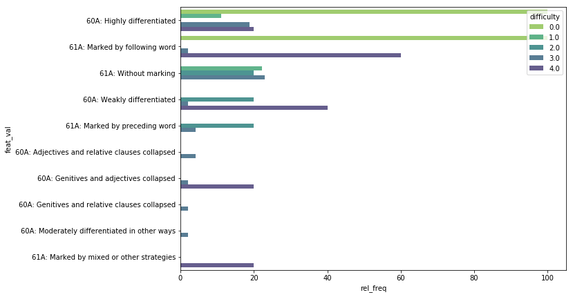

```python
fig=plt.figure(figsize=[10,7])
adjectives = rel_freq.query('ID_num>=60 & ID_num<=61')
sb.barplot(data=adjectives,y='feat_val',x='rel_freq',hue='difficulty',palette='viridis_r',alpha=0.85);
```

**Feats 62-64: Nouns**

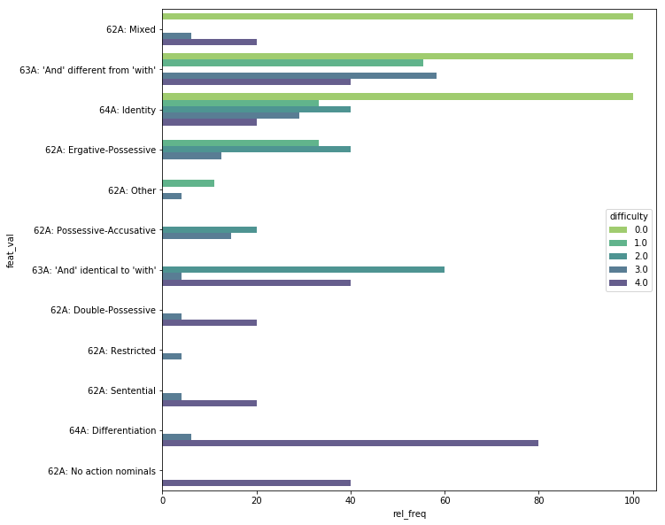

```python
fig=plt.figure(figsize=[10,10])
nouns = rel_freq.query('ID_num>=62 & ID_num<=64')
sb.barplot(data=nouns,y='feat_val',x='rel_freq',hue='difficulty',palette='viridis_r',alpha=0.85);
```

*Preliminary findings:*

- We see the same distinction between more difficult languages using differentiation and easier languages using identity (64A).

**Feats 65-80: Tense and aspect (and suppletion)**

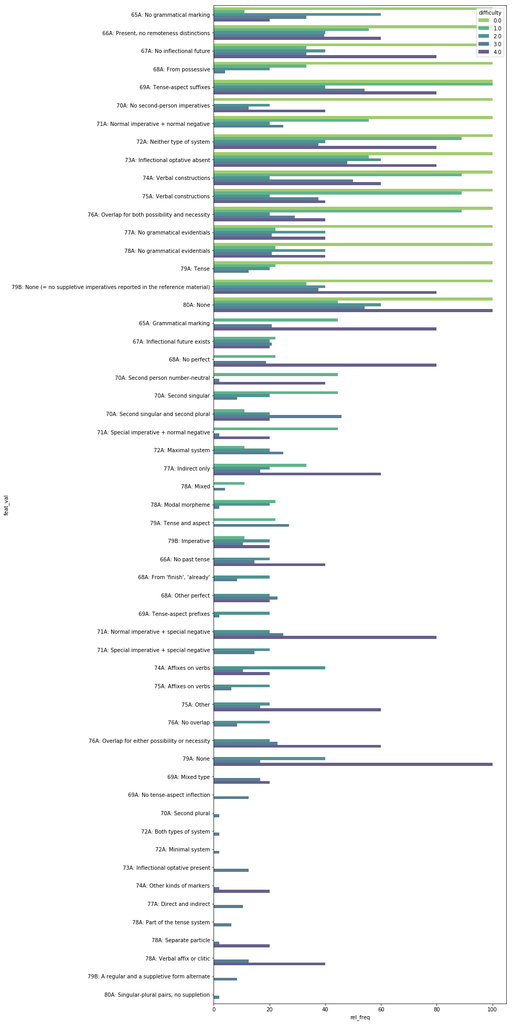

```python
fig=plt.figure(figsize=[10,35])
tense = rel_freq.query('ID_num>=65 & ID_num<=80')
sb.barplot(data=tense,y='feat_val',x='rel_freq',hue='difficulty',palette='viridis_r',alpha=0.85);
```

*Preliminary findings:*

- Suppletion is when verbs of different tenses show no phonological similarities, such as go and went in English. None of the difficult languages use suppletion, whereas English and some of the easier languages show suppletion across tense. Clearly this occurence is not driving the difficulty of the category IV languages.

**Feats 81-89: Sentence structure and order**

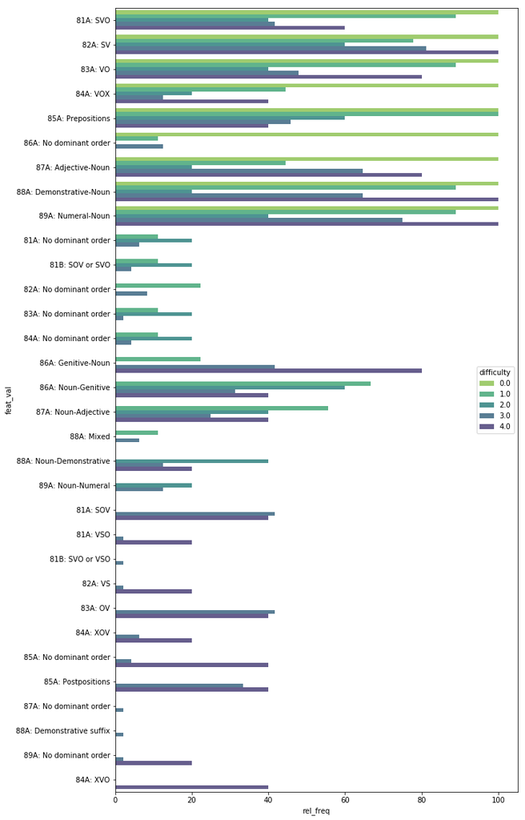

```python
fig=plt.figure(figsize=[10,20])
structure = rel_freq.query('ID_num>=81 & ID_num<=89')
sb.barplot(data=structure,y='feat_val',x='rel_freq',hue='difficulty',palette='viridis_r',alpha=0.85);
```

*Preliminary findings:*

- The world is much divided into languages that use prepositions and languages that use postpositions. English and the many easier languages use prepositions only, whereas some category III and IV languages use postpositions (35% and 40%, respectively). Another 40% of category IV languages use more than one adposition.

**Feat 90: Relative clauses**

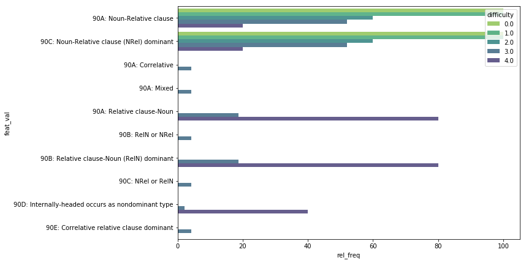

```python
fig=plt.figure(figsize=[10,7])
rel_clause = rel_freq.query('ID_num==90')
sb.barplot(data=rel_clause,y='feat_val',x='rel_freq',hue='difficulty',palette='viridis_r',alpha=0.85);
```

*Preliminary findings:*

- As with adpositions, we see a similar divide between languages that place the relative clause after versus before the noun. Difficult languages more often place the relative clause before, whereas English and the easier languages are more likely to place it after the noun.

**Feats 91-97: More order**

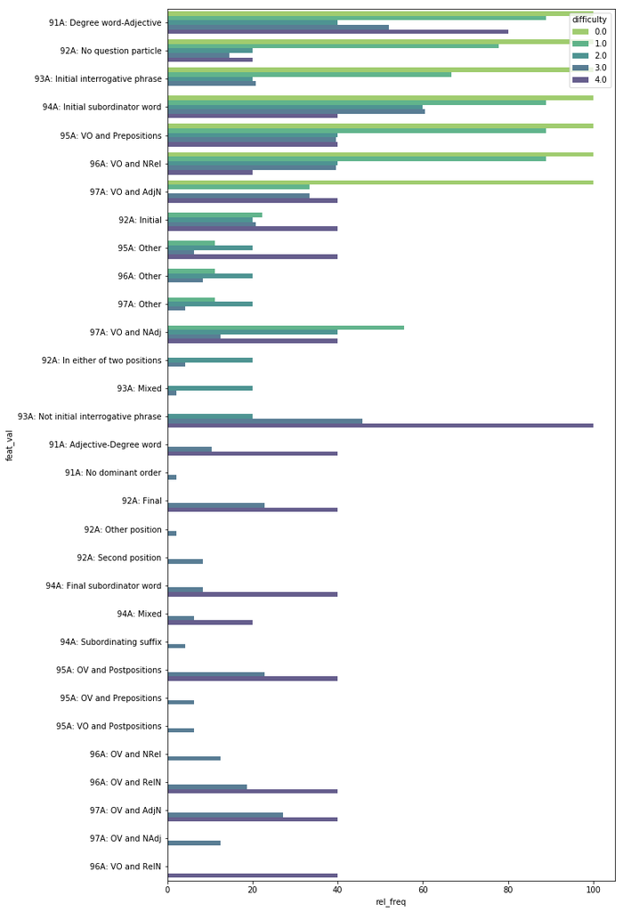

```python
fig=plt.figure(figsize=[10,20])
order_2 = rel_freq.query('ID_num>=91 & ID_num<=97')
sb.barplot(data=order_2,y='feat_val',x='rel_freq',hue='difficulty',palette='viridis_r',alpha=0.85);
```

*Preliminary findings:*

- English requires an interrogative phrase at the beginning of a sentence (ex. Who/What/Where), whereas category IV languages place it somewhere else in the sentence (93A).
- Most languages can either be categorized as "Verb-Object and Prepositions" (like English and easier languages) or "Object-Verb and Postpositions" (more common across the difficult languages). (95A)

**Feats 98-104: Person marking**

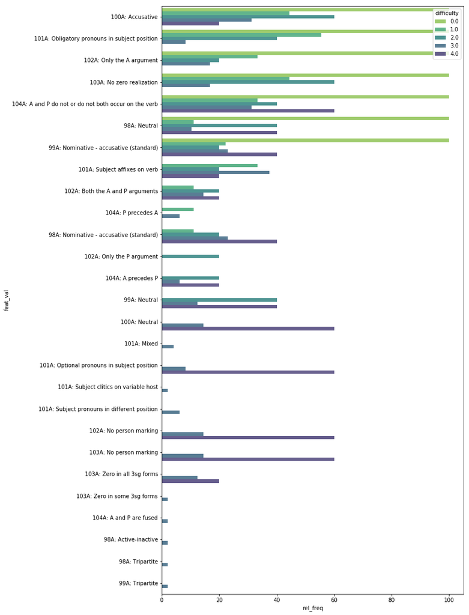

```python
fig=plt.figure(figsize=[10,20])
person_marking = rel_freq.query('ID_num>=98 & ID_num<=104')
sb.barplot(data=person_marking,y='feat_val',x='rel_freq',hue='difficulty',palette='viridis_r',alpha=0.85);
```

*Preliminary Findings:*

- The category IV languages are more likely to have no verbal person marking. This is not common worldwide, with only 84/380 of the languages lacking alignment. English and most of the easier languages have some form of alignment. https://wals.info/chapter/100

**Feats 105-111: Constructions (active, passive, reciprocal etc.)**

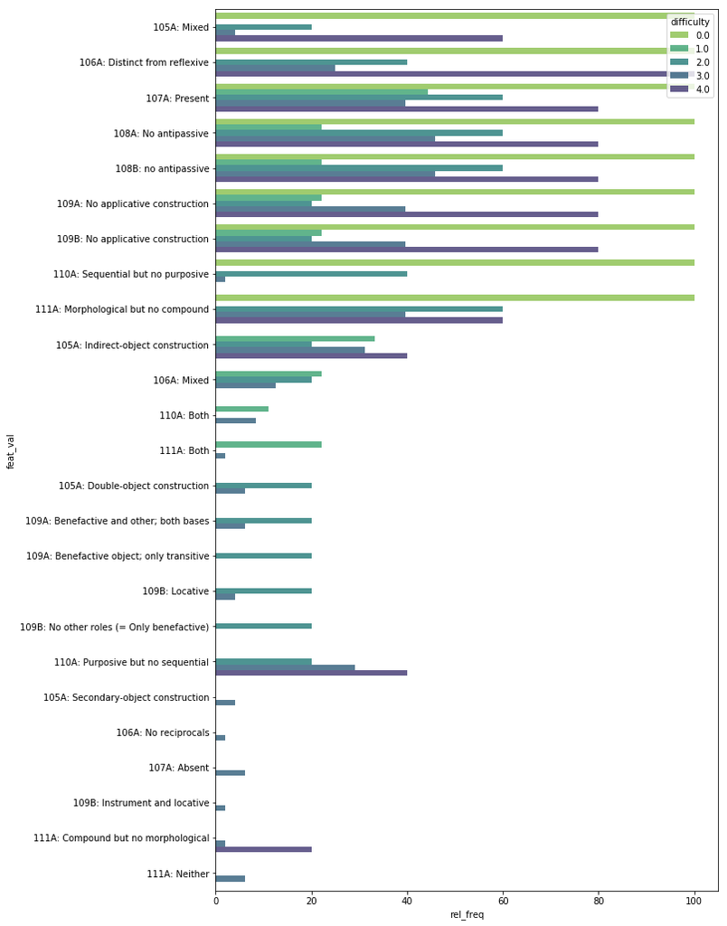

```python
fig=plt.figure(figsize=[10,18])
constructions = rel_freq.query('ID_num>=105 & ID_num<=111')
sb.barplot(data=constructions,y='feat_val',x='rel_freq',hue='difficulty',palette='viridis_r',alpha=0.85);
```

**Feats 112-115, 143: Negation**

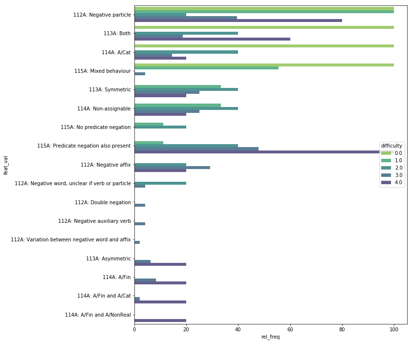

```python
fig=plt.figure(figsize=[10,12])
negation = rel_freq.query('ID_num>=112 & ID_num<=115')
sb.barplot(data=negation,y='feat_val',x='rel_freq',hue='difficulty',palette='viridis_r',alpha=0.85);
```

*Preliminary findings:*

- Much of the world's languages, including all of the category IV languages, always use a predicate negation along with a negative indefinite pronoun such as "nobody". English and other Western European langauges are the few that often do not use this feature.

The "ne" in Russian is an example of predicate negation:

> Nikto ne prišel.

> nobody `neg` came.

> 'Nobody came.'

https://wals.info/chapter/115

**Feat 116: Polar questions**

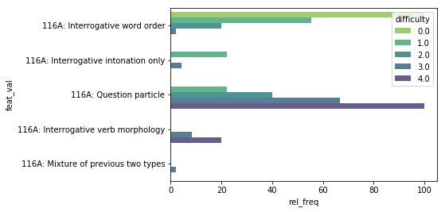

```python
polar_qs = rel_freq.query('ID_num==116')
sb.barplot(data=polar_qs,y='feat_val',x='rel_freq',hue='difficulty',palette='viridis_r',alpha=0.85);
```

*Preliminary findings:*

- Again much of the worlds languages, including all of the category IV, use a question particle, whereas English and other Western European languages often use an interrogative word such as "who/what/where".

**Feats 117-120: Predication**

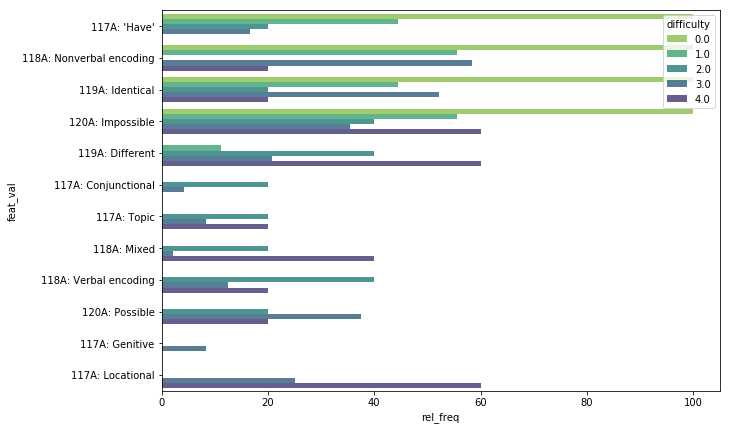

```python
fig=plt.figure(figsize=[10,7])
predication = rel_freq.query('ID_num>=117 & ID_num<=120')
sb.barplot(data=predication,y='feat_val',x='rel_freq',hue='difficulty',palette='viridis_r',alpha=0.85);
```

*Preliminary Findings:*

- Predication is another feature that is divided geographically. In English, "have/has" is used to indicate possession. Other Western European languages have a similar construction. Conversely, the category III langauges use genetive, topical, and conjunctional possessives. The majority of category IV languages use a locational possessive which translates to something like "to be at" or "to exist". Here is an example in Mongolic:

> na-dur morin bui